# Codebook example formr

Ruben Arslan

2019-02-19

```r
knitr::opts_chunk$set(warning = TRUE, message = TRUE, echo = FALSE, error = FALSE)
pander::panderOptions("table.split.table", Inf)
library(codebook)
data("bfi", package = 'codebook')
bfi2 = zap_attributes(bfi)
bfi2[,1:5] <- bfi[,1:5]
bfi <- bfi2
bfi$age <- 1:nrow(bfi)
bfi$abode <- rep("my happy place", times = nrow(bfi))
var_label(bfi$abode) <- "Where do you live?"
bfi$uniq_id <- as.character(1:nrow(bfi))
var_label(bfi$uniq_id) <- "Unique ID"

ggplot2::theme_set(ggplot2::theme_bw())
pander::panderOptions("table.split.table", Inf)
bfi$age <- rpois(nrow(bfi), 30)
# class(bfi$age) = c("udhfibr")
bfi <- detect_scales(bfi)
```

```
#> 4 BFIK_open items connected to scale
#> 4 BFIK_agree items connected to scale
#> 4 BFIK_extra items connected to scale
#> 3 BFIK_neuro items connected to scale
#> 4 BFIK_consc items connected to scale
```

### Metadata

#### Description

**Dataset name**: bfi

The dataset has N=28 rows and 32 columns. 0 rows have no missing values on any column.

**Metadata for search engines**

- **Date published**: 2019-02-19
  - **keywords**: *session*, *created*, *modified*, *ended*, *expired*, *BFIK_open_2*, *BFIK_agree_4R*, *BFIK_extra_2*, *BFIK_agree_1R*, *BFIK_open_1*, *BFIK_neuro_2R*, *BFIK_consc_3*, *BFIK_consc_4*, *BFIK_consc_2R*, *BFIK_agree_3R*, *BFIK_extra_3R*, *BFIK_neuro_3*, *BFIK_neuro_4*, *BFIK_agree_2*, *BFIK_consc_1*, *BFIK_open_4*, *BFIK_extra_4*, *BFIK_extra_1R*, *BFIK_open_3*, *BFIK_agree*, *BFIK_open*, *BFIK_consc*, *BFIK_extra*, *BFIK_neuro*, *age*, *abode* and *uniq_id*

### Survey overview

28 completed rows, 28 who entered any information, 0 only viewed the first page. There are 0 expired rows (people who did not finish filling out in the requested time frame). In total, there are 28 rows including unfinished and expired rows.

There were 28 unique participants, of which 28 finished filling out at least one survey.

This survey was not repeated.

The first session started on 2016-07-08 09:54:16, the last session on 2016-11-02 21:19:50.

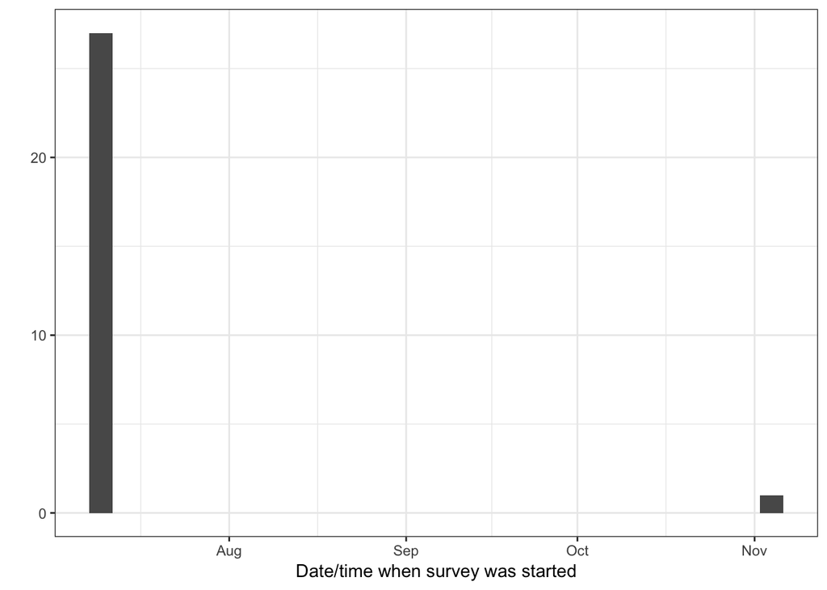

People took on average 127.36 minutes (median 1.48) to answer the survey.

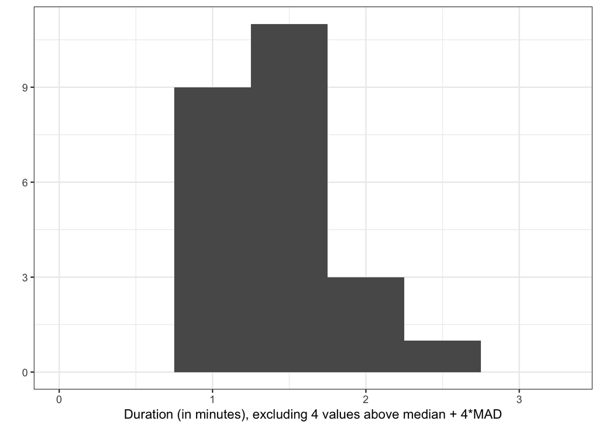

## Variables

### Scale: BFIK_agree

#### Overview

**Reliability**: Cronbach’s α [95% CI] = 0.8 [0.68;0.92].

**Missing**: 0.

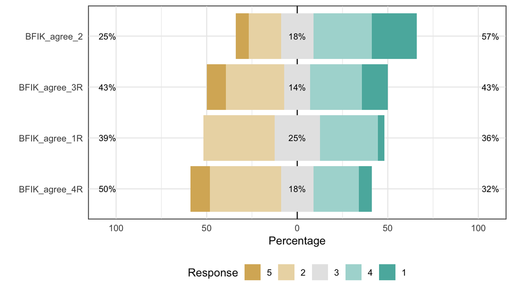

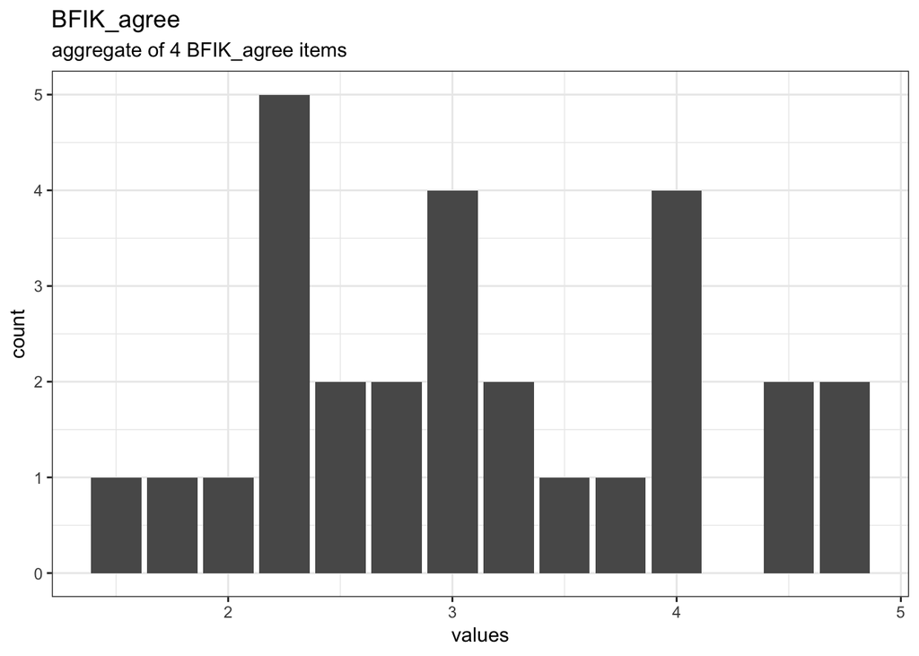

#### Reliability details

##### Reliability

##### 95% Confidence Interval

| lower | estimate | upper |
| --- | --- | --- |
| 0.6815 | 0.8006 | 0.9196 |

| raw_alpha | std.alpha | G6(smc) | average_r | S/N | ase | mean | sd | median_r |
| --- | --- | --- | --- | --- | --- | --- | --- | --- |
| 0.8006 | 0.8033 | 0.8025 | 0.5051 | 4.083 | 0.06074 | 3.116 | 0.9317 | 0.4955 |

##### Reliability if an item is dropped:

|  | raw_alpha | std.alpha | G6(smc) | average_r | S/N | alpha se | var.r | med.r |
| --- | --- | --- | --- | --- | --- | --- | --- | --- |
| **BFIK_agree_4R** | 0.7039 | 0.7059 | 0.6277 | 0.4445 | 2.4 | 0.09224 | 0.009329 | 0.4566 |
| **BFIK_agree_1R** | 0.7823 | 0.7822 | 0.7633 | 0.5448 | 3.591 | 0.0731 | 0.04131 | 0.5344 |
| **BFIK_agree_3R** | 0.6759 | 0.6926 | 0.6242 | 0.4289 | 2.253 | 0.1072 | 0.02125 | 0.347 |
| **BFIK_agree_2** | 0.8181 | 0.8196 | 0.7841 | 0.6023 | 4.543 | 0.05685 | 0.022 | 0.5972 |

##### Item statistics

|  | n | raw.r | std.r | r.cor | r.drop | mean | sd |
| --- | --- | --- | --- | --- | --- | --- | --- |
| **BFIK_agree_4R** | 28 | 0.8471 | 0.8503 | 0.8292 | 0.7058 | 2.929 | 1.184 |
| **BFIK_agree_1R** | 28 | 0.7168 | 0.7554 | 0.6254 | 0.5539 | 3 | 0.9428 |
| **BFIK_agree_3R** | 28 | 0.8821 | 0.8651 | 0.8439 | 0.751 | 3.036 | 1.29 |
| **BFIK_agree_2** | 28 | 0.7206 | 0.7011 | 0.5431 | 0.4825 | 3.5 | 1.262 |

##### Non missing response frequency for each item

|  | 1 | 2 | 3 | 4 | 5 | miss |
| --- | --- | --- | --- | --- | --- | --- |
| **BFIK_agree_4R** | 0.07143 | 0.3929 | 0.1786 | 0.25 | 0.1071 | 0 |
| **BFIK_agree_1R** | 0 | 0.3929 | 0.25 | 0.3214 | 0.03571 | 0 |
| **BFIK_agree_3R** | 0.1071 | 0.3214 | 0.1429 | 0.2857 | 0.1429 | 0 |
| **BFIK_agree_2** | 0.07143 | 0.1786 | 0.1786 | 0.3214 | 0.25 | 0 |

#### Summary statistics

| name | data_type | missing | complete | n | mean | sd | p0 | p25 | p50 | p75 | p100 | hist |
| --- | --- | --- | --- | --- | --- | --- | --- | --- | --- | --- | --- | --- |
| BFIK_agree_4R | numeric | 0 | 28 | 28 | 2.93 | 1.18 | 1 | 2 | 3 | 4 | 5 | ▂▇▁▃▁▅▁▂ |
| BFIK_agree_1R | numeric | 0 | 28 | 28 | 3 | 0.94 | 2 | 2 | 3 | 4 | 5 | ▇▁▅▁▁▆▁▁ |
| BFIK_agree_3R | numeric | 0 | 28 | 28 | 3.04 | 1.29 | 1 | 2 | 3 | 4 | 5 | ▂▇▁▃▁▇▁▃ |
| BFIK_agree_2 | numeric | 0 | 28 | 28 | 3.5 | 1.26 | 1 | 2.75 | 4 | 4.25 | 5 | ▂▅▁▅▁▇▁▆ |

### Scale: BFIK_open

#### Overview

**Reliability**: Cronbach’s α [95% CI] = 0.53 [0.25;0.81].

**Missing**: 0.

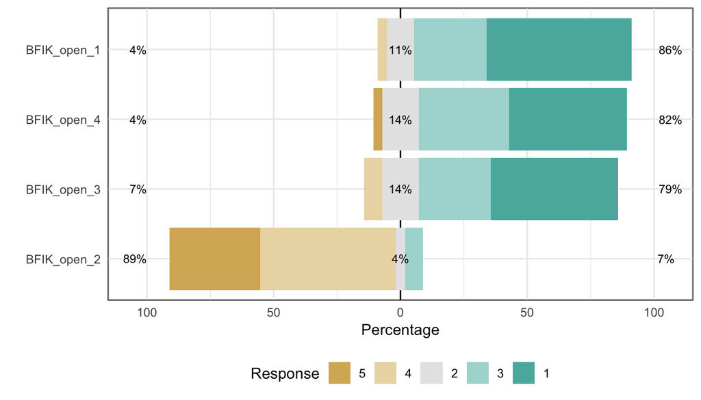

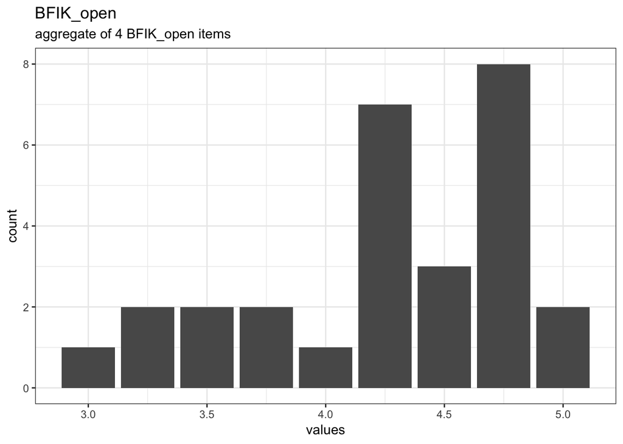

#### Reliability details

##### Reliability

##### 95% Confidence Interval

| lower | estimate | upper |
| --- | --- | --- |
| 0.2473 | 0.5271 | 0.8068 |

| raw_alpha | std.alpha | G6(smc) | average_r | S/N | ase | mean | sd | median_r |
| --- | --- | --- | --- | --- | --- | --- | --- | --- |
| 0.5271 | 0.513 | 0.5384 | 0.2085 | 1.054 | 0.1427 | 4.259 | 0.5631 | 0.1771 |

##### Reliability if an item is dropped:

|  | raw_alpha | std.alpha | G6(smc) | average_r | S/N | alpha se | var.r | med.r |
| --- | --- | --- | --- | --- | --- | --- | --- | --- |
| **BFIK_open_2** | 0.5187 | 0.5019 | 0.5306 | 0.2515 | 1.008 | 0.1551 | 0.0956 | 0.2626 |
| **BFIK_open_1** | 0.5787 | 0.5594 | 0.513 | 0.2973 | 1.269 | 0.1308 | 0.05045 | 0.1948 |
| **BFIK_open_4** | 0.4119 | 0.4101 | 0.3218 | 0.1881 | 0.6952 | 0.1885 | 0.004236 | 0.1594 |
| **BFIK_open_3** | 0.2202 | 0.2437 | 0.2042 | 0.09701 | 0.3223 | 0.2572 | 0.01955 | 0.1594 |

##### Item statistics

|  | n | raw.r | std.r | r.cor | r.drop | mean | sd |
| --- | --- | --- | --- | --- | --- | --- | --- |
| **BFIK_open_2** | 28 | 0.5298 | 0.5869 | 0.3017 | 0.2318 | 4.214 | 0.7382 |
| **BFIK_open_1** | 28 | 0.5063 | 0.5329 | 0.2761 | 0.1569 | 4.393 | 0.8317 |
| **BFIK_open_4** | 28 | 0.701 | 0.6614 | 0.5679 | 0.3612 | 4.214 | 0.9567 |
| **BFIK_open_3** | 28 | 0.8041 | 0.7686 | 0.7253 | 0.538 | 4.214 | 0.9567 |

##### Non missing response frequency for each item

|  | 1 | 2 | 3 | 4 | 5 | miss |
| --- | --- | --- | --- | --- | --- | --- |
| **BFIK_open_2** | 0 | 0.03571 | 0.07143 | 0.5357 | 0.3571 | 0 |
| **BFIK_open_1** | 0 | 0.03571 | 0.1071 | 0.2857 | 0.5714 | 0 |
| **BFIK_open_4** | 0.03571 | 0 | 0.1429 | 0.3571 | 0.4643 | 0 |
| **BFIK_open_3** | 0 | 0.07143 | 0.1429 | 0.2857 | 0.5 | 0 |

#### Summary statistics

| name | data_type | missing | complete | n | mean | sd | p0 | p25 | p50 | p75 | p100 | hist |
| --- | --- | --- | --- | --- | --- | --- | --- | --- | --- | --- | --- | --- |
| BFIK_open_2 | numeric | 0 | 28 | 28 | 4.21 | 0.74 | 2 | 4 | 4 | 5 | 5 | ▁▁▁▁▁▇▁▅ |
| BFIK_open_1 | numeric | 0 | 28 | 28 | 4.39 | 0.83 | 2 | 4 | 5 | 5 | 5 | ▁▁▂▁▁▃▁▇ |
| BFIK_open_4 | numeric | 0 | 28 | 28 | 4.21 | 0.96 | 1 | 4 | 4 | 5 | 5 | ▁▁▁▂▁▆▁▇ |
| BFIK_open_3 | numeric | 0 | 28 | 28 | 4.21 | 0.96 | 2 | 4 | 4.5 | 5 | 5 | ▁▁▂▁▁▅▁▇ |

### Scale: BFIK_consc

#### Overview

**Reliability**: Cronbach’s α [95% CI] = 0.78 [0.66;0.9].

**Missing**: 0.

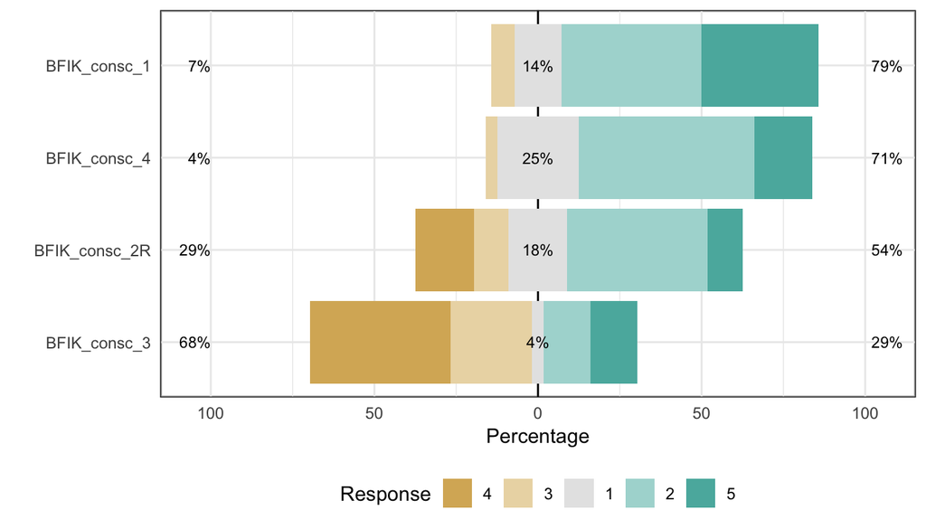

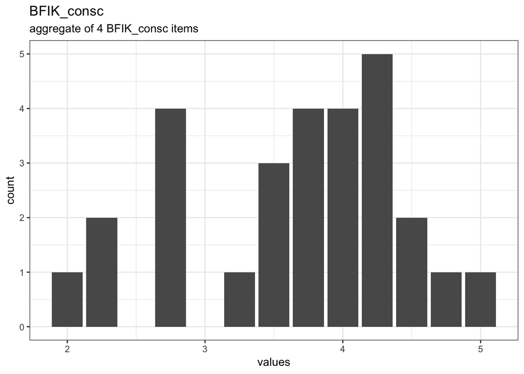

#### Reliability details

##### Reliability

##### 95% Confidence Interval

| lower | estimate | upper |
| --- | --- | --- |
| 0.6573 | 0.7797 | 0.9021 |

| raw_alpha | std.alpha | G6(smc) | average_r | S/N | ase | mean | sd | median_r |
| --- | --- | --- | --- | --- | --- | --- | --- | --- |
| 0.7797 | 0.7871 | 0.7839 | 0.4803 | 3.696 | 0.06246 | 3.652 | 0.7916 | 0.459 |

##### Reliability if an item is dropped:

|  | raw_alpha | std.alpha | G6(smc) | average_r | S/N | alpha se | var.r | med.r |
| --- | --- | --- | --- | --- | --- | --- | --- | --- |
| **BFIK_consc_3** | 0.598 | 0.6118 | 0.5248 | 0.3445 | 1.576 | 0.1176 | 0.009255 | 0.3983 |
| **BFIK_consc_4** | 0.7626 | 0.7706 | 0.7159 | 0.5282 | 3.359 | 0.07398 | 0.01857 | 0.5164 |
| **BFIK_consc_2R** | 0.7284 | 0.7272 | 0.7112 | 0.4705 | 2.666 | 0.08493 | 0.04747 | 0.5164 |
| **BFIK_consc_1** | 0.7813 | 0.8042 | 0.7721 | 0.5779 | 4.107 | 0.0663 | 0.02329 | 0.6619 |

##### Item statistics

|  | n | raw.r | std.r | r.cor | r.drop | mean | sd |
| --- | --- | --- | --- | --- | --- | --- | --- |
| **BFIK_consc_3** | 28 | 0.9086 | 0.9115 | 0.9169 | 0.8121 | 3.5 | 1.036 |
| **BFIK_consc_4** | 28 | 0.6875 | 0.7351 | 0.6337 | 0.5257 | 3.857 | 0.7559 |
| **BFIK_consc_2R** | 28 | 0.8411 | 0.7905 | 0.6957 | 0.6209 | 3.179 | 1.307 |
| **BFIK_consc_1** | 28 | 0.6733 | 0.6874 | 0.5202 | 0.4657 | 4.071 | 0.8997 |

##### Non missing response frequency for each item

|  | 1 | 2 | 3 | 4 | 5 | miss |
| --- | --- | --- | --- | --- | --- | --- |
| **BFIK_consc_3** | 0.03571 | 0.1429 | 0.25 | 0.4286 | 0.1429 | 0 |
| **BFIK_consc_4** | 0 | 0.03571 | 0.25 | 0.5357 | 0.1786 | 0 |
| **BFIK_consc_2R** | 0.1786 | 0.1071 | 0.1786 | 0.4286 | 0.1071 | 0 |
| **BFIK_consc_1** | 0 | 0.07143 | 0.1429 | 0.4286 | 0.3571 | 0 |

#### Summary statistics

| name | data_type | missing | complete | n | mean | sd | p0 | p25 | p50 | p75 | p100 | hist |
| --- | --- | --- | --- | --- | --- | --- | --- | --- | --- | --- | --- | --- |
| BFIK_consc_3 | numeric | 0 | 28 | 28 | 3.5 | 1.04 | 1 | 3 | 4 | 4 | 5 | ▁▂▁▅▁▇▁▂ |
| BFIK_consc_4 | numeric | 0 | 28 | 28 | 3.86 | 0.76 | 2 | 3 | 4 | 4 | 5 | ▁▁▃▁▁▇▁▂ |
| BFIK_consc_2R | numeric | 0 | 28 | 28 | 3.18 | 1.31 | 1 | 2 | 4 | 4 | 5 | ▃▂▁▃▁▇▁▂ |
| BFIK_consc_1 | numeric | 0 | 28 | 28 | 4.07 | 0.9 | 2 | 4 | 4 | 5 | 5 | ▁▁▂▁▁▇▁▇ |

### Scale: BFIK_extra

#### Overview

**Reliability**: Cronbach’s α [95% CI] = 0.9 [0.84;0.96].

**Missing**: 0.

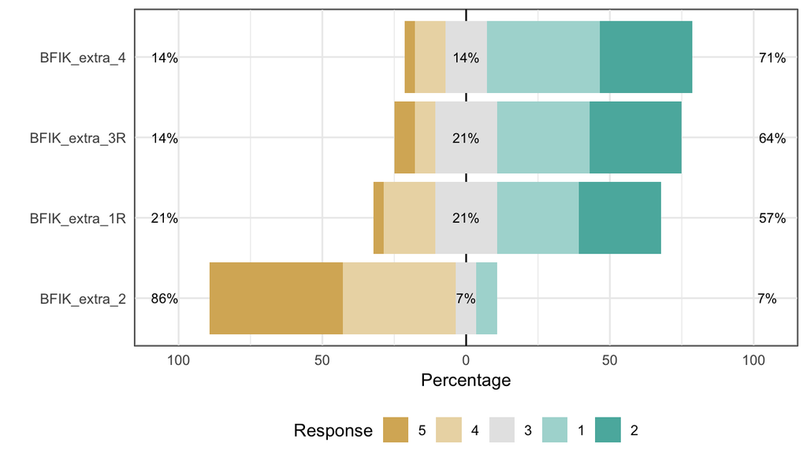

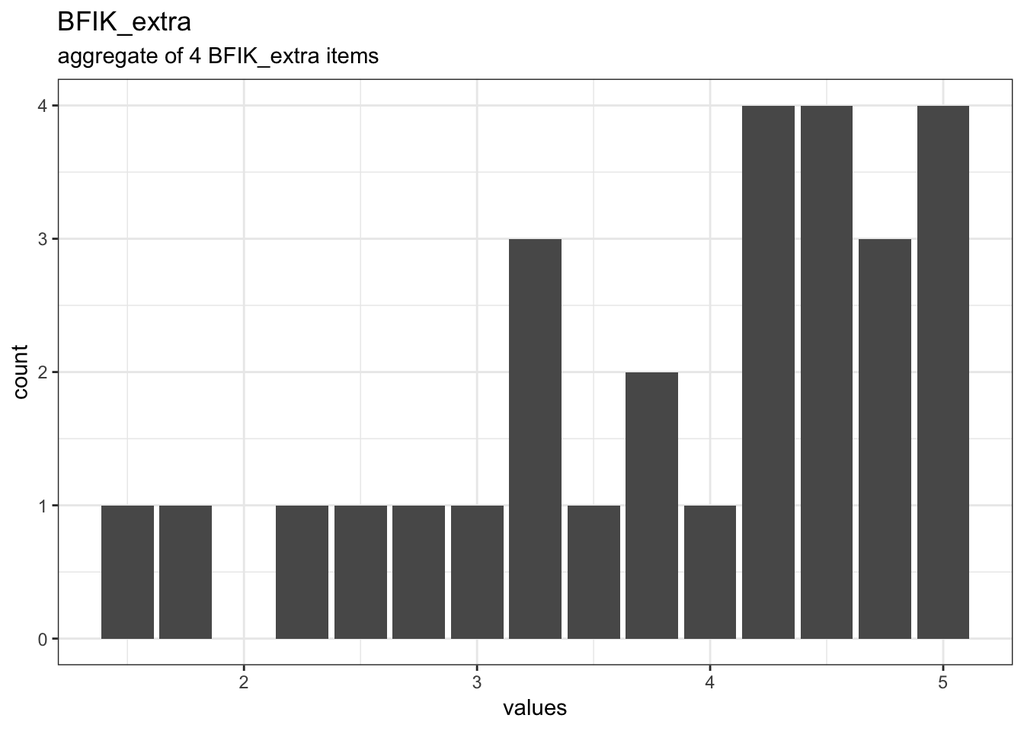

#### Reliability details

##### Reliability

##### 95% Confidence Interval

| lower | estimate | upper |
| --- | --- | --- |
| 0.8369 | 0.8993 | 0.9617 |

| raw_alpha | std.alpha | G6(smc) | average_r | S/N | ase | mean | sd | median_r |
| --- | --- | --- | --- | --- | --- | --- | --- | --- |
| 0.8993 | 0.8991 | 0.9104 | 0.6902 | 8.914 | 0.03184 | 3.848 | 1.01 | 0.6932 |

##### Reliability if an item is dropped:

|  | raw_alpha | std.alpha | G6(smc) | average_r | S/N | alpha se | var.r | med.r |
| --- | --- | --- | --- | --- | --- | --- | --- | --- |
| **BFIK_extra_2** | 0.905 | 0.9049 | 0.881 | 0.7603 | 9.515 | 0.0315 | 0.007506 | 0.7906 |
| **BFIK_extra_3R** | 0.8657 | 0.8667 | 0.8459 | 0.6842 | 6.5 | 0.04531 | 0.01711 | 0.7239 |
| **BFIK_extra_4** | 0.8526 | 0.8505 | 0.8225 | 0.6548 | 5.691 | 0.0488 | 0.02333 | 0.5986 |
| **BFIK_extra_1R** | 0.8524 | 0.8544 | 0.8026 | 0.6617 | 5.867 | 0.04871 | 0.003923 | 0.6626 |

##### Item statistics

|  | n | raw.r | std.r | r.cor | r.drop | mean | sd |
| --- | --- | --- | --- | --- | --- | --- | --- |
| **BFIK_extra_2** | 28 | 0.8074 | 0.8162 | 0.7345 | 0.6734 | 4.179 | 1.09 |
| **BFIK_extra_3R** | 28 | 0.8877 | 0.8814 | 0.8432 | 0.788 | 3.75 | 1.206 |
| **BFIK_extra_4** | 28 | 0.9028 | 0.9065 | 0.8788 | 0.8248 | 3.857 | 1.113 |
| **BFIK_extra_1R** | 28 | 0.9063 | 0.9006 | 0.8875 | 0.822 | 3.607 | 1.197 |

##### Non missing response frequency for each item

|  | 1 | 2 | 3 | 4 | 5 | miss |
| --- | --- | --- | --- | --- | --- | --- |
| **BFIK_extra_2** | 0.07143 | 0 | 0.07143 | 0.3929 | 0.4643 | 0 |
| **BFIK_extra_3R** | 0.07143 | 0.07143 | 0.2143 | 0.3214 | 0.3214 | 0 |
| **BFIK_extra_4** | 0.03571 | 0.1071 | 0.1429 | 0.3929 | 0.3214 | 0 |
| **BFIK_extra_1R** | 0.03571 | 0.1786 | 0.2143 | 0.2857 | 0.2857 | 0 |

#### Summary statistics

| name | data_type | missing | complete | n | mean | sd | p0 | p25 | p50 | p75 | p100 | hist |
| --- | --- | --- | --- | --- | --- | --- | --- | --- | --- | --- | --- | --- |
| BFIK_extra_2 | numeric | 0 | 28 | 28 | 4.18 | 1.09 | 1 | 4 | 4 | 5 | 5 | ▁▁▁▁▁▇▁▇ |
| BFIK_extra_3R | numeric | 0 | 28 | 28 | 3.75 | 1.21 | 1 | 3 | 4 | 5 | 5 | ▂▂▁▅▁▇▁▇ |
| BFIK_extra_4 | numeric | 0 | 28 | 28 | 3.86 | 1.11 | 1 | 3 | 4 | 5 | 5 | ▁▂▁▃▁▇▁▆ |
| BFIK_extra_1R | numeric | 0 | 28 | 28 | 3.61 | 1.2 | 1 | 3 | 4 | 5 | 5 | ▁▅▁▆▁▇▁▇ |

### Scale: BFIK_neuro

#### Overview

**Reliability**: Cronbach’s α [95% CI] = 0.75 [0.61;0.9].

**Missing**: 0.

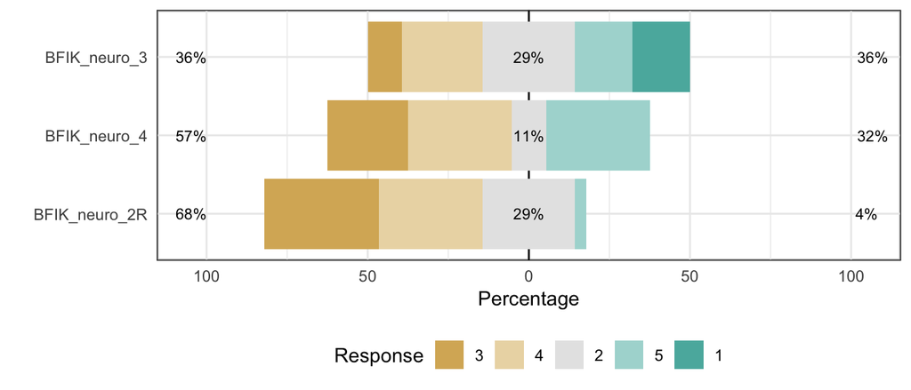

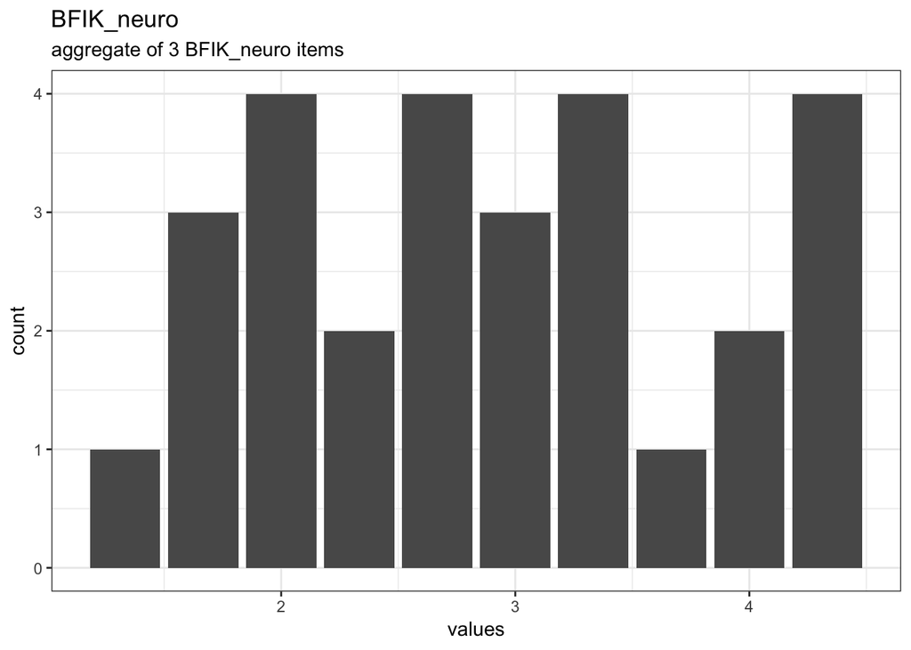

#### Reliability details

##### Reliability

##### 95% Confidence Interval

| lower | estimate | upper |
| --- | --- | --- |
| 0.6081 | 0.7537 | 0.8994 |

| raw_alpha | std.alpha | G6(smc) | average_r | S/N | ase | mean | sd | median_r |
| --- | --- | --- | --- | --- | --- | --- | --- | --- |
| 0.7537 | 0.7476 | 0.7146 | 0.4968 | 2.962 | 0.07432 | 2.893 | 0.9254 | 0.4402 |

##### Reliability if an item is dropped:

|  | raw_alpha | std.alpha | G6(smc) | average_r | S/N | alpha se | var.r | med.r |
| --- | --- | --- | --- | --- | --- | --- | --- | --- |
| **BFIK_neuro_2R** | 0.84 | 0.8408 | 0.7254 | 0.7254 | 5.283 | 0.06026 | NA | 0.7254 |
| **BFIK_neuro_3** | 0.5905 | 0.6113 | 0.4402 | 0.4402 | 1.572 | 0.1457 | NA | 0.4402 |
| **BFIK_neuro_4** | 0.4654 | 0.4905 | 0.3249 | 0.3249 | 0.9627 | 0.1872 | NA | 0.3249 |

##### Item statistics

|  | n | raw.r | std.r | r.cor | r.drop | mean | sd |
| --- | --- | --- | --- | --- | --- | --- | --- |
| **BFIK_neuro_2R** | 28 | 0.6549 | 0.7217 | 0.4638 | 0.41 | 3.107 | 0.8751 |
| **BFIK_neuro_3** | 28 | 0.8755 | 0.8384 | 0.7626 | 0.6529 | 3.071 | 1.274 |
| **BFIK_neuro_4** | 28 | 0.9047 | 0.8855 | 0.8409 | 0.7421 | 2.5 | 1.202 |

##### Non missing response frequency for each item

|  | 1 | 2 | 3 | 4 | 5 | miss |
| --- | --- | --- | --- | --- | --- | --- |
| **BFIK_neuro_2R** | 0 | 0.2857 | 0.3571 | 0.3214 | 0.03571 | 0 |
| **BFIK_neuro_3** | 0.1071 | 0.25 | 0.2857 | 0.1786 | 0.1786 | 0 |
| **BFIK_neuro_4** | 0.25 | 0.3214 | 0.1071 | 0.3214 | 0 | 0 |

#### Summary statistics

| name | data_type | missing | complete | n | mean | sd | p0 | p25 | p50 | p75 | p100 | hist |
| --- | --- | --- | --- | --- | --- | --- | --- | --- | --- | --- | --- | --- |
| BFIK_neuro_2R | numeric | 0 | 28 | 28 | 3.11 | 0.88 | 2 | 2 | 3 | 4 | 5 | ▆▁▇▁▁▇▁▁ |
| BFIK_neuro_3 | numeric | 0 | 28 | 28 | 3.07 | 1.27 | 1 | 2 | 3 | 4 | 5 | ▃▇▁▇▁▅▁▅ |
| BFIK_neuro_4 | numeric | 0 | 28 | 28 | 2.5 | 1.2 | 1 | 1.75 | 2 | 4 | 4 | ▆▁▇▁▁▂▁▇ |

### age

#### Distribution

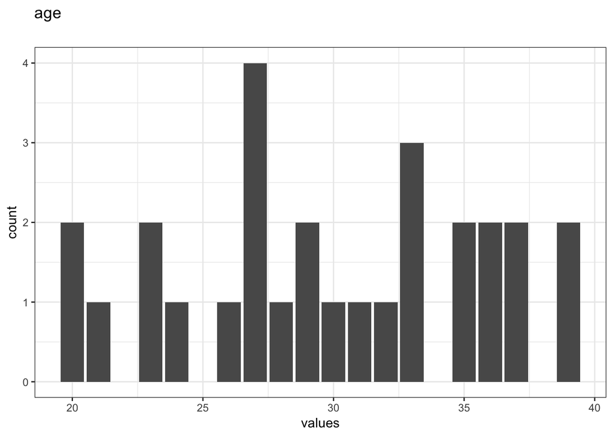

0 missing values.

#### Summary statistics

| name | data_type | missing | complete | n | mean | sd | p0 | p25 | p50 | p75 | p100 | hist |
| --- | --- | --- | --- | --- | --- | --- | --- | --- | --- | --- | --- | --- |
| age | integer | 0 | 28 | 28 | 29.89 | 5.73 | 20 | 26.75 | 29.5 | 35 | 39 | ▅▅▇▅▃▆▆▆ |

### abode

Where do you live?

#### Distribution

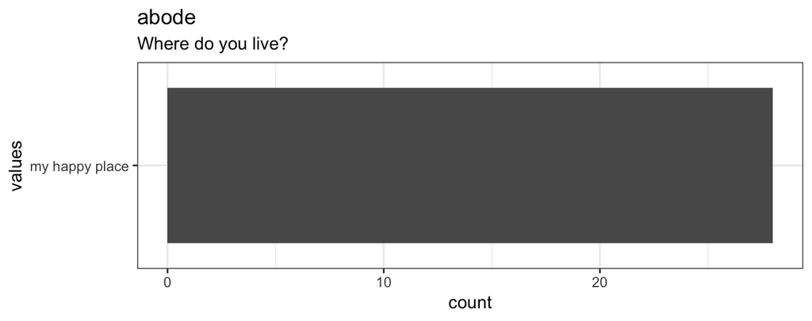

0 missing values.

#### Summary statistics

| name | label | data_type | missing | complete | n | empty | n_unique | min | max |
| --- | --- | --- | --- | --- | --- | --- | --- | --- | --- |
| abode | Where do you live? | character | 0 | 28 | 28 | 0 | 1 | 14 | 14 |

### uniq_id

Unique ID

#### Distribution

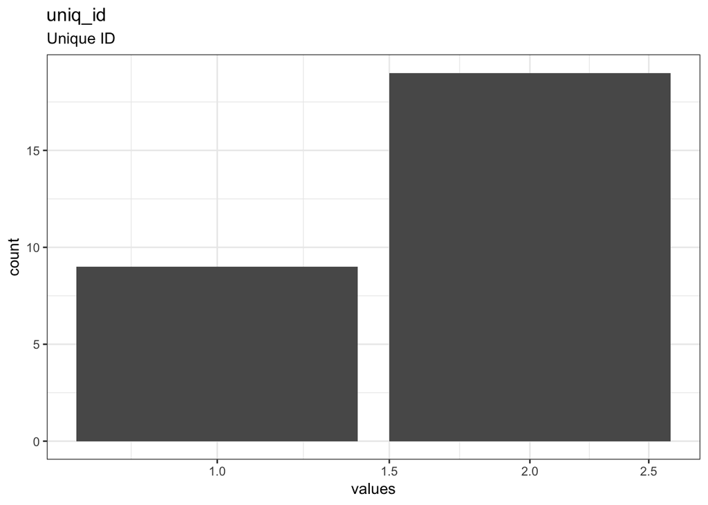

0 missing values.

#### Summary statistics

| name | label | data_type | missing | complete | n | empty | n_unique | min | max |
| --- | --- | --- | --- | --- | --- | --- | --- | --- | --- |
| uniq_id | Unique ID | character | 0 | 28 | 28 | 0 | 28 | 1 | 2 |

## Missingness report

| description | expired | var_miss | n_miss |
| --- | --- | --- | --- |
| Missing values in 1 variables | 0 | 1 | 28 |
| Missing values per variable | 28 | 28 | 28 |

## Codebook table

| name | label | data_type | scale_item_names | missing | complete | n | empty | n_unique | count | median | min | max | mean | sd | p0 | p25 | p50 | p75 | p100 | hist |
| --- | --- | --- | --- | --- | --- | --- | --- | --- | --- | --- | --- | --- | --- | --- | --- | --- | --- | --- | --- | --- |
| session |  | character |  | 0 | 28 | 28 | 0 | 28 |  |  | 64 | 64 |  |  |  |  |  |  |  |  |
| created | user first opened survey | POSIXct |  | 0 | 28 | 28 |  | 28 |  | 2016-07-08 | 2016-07-08 | 2016-11-02 |  |  |  |  |  |  |  |  |
| modified | user last edited survey | POSIXct |  | 0 | 28 | 28 |  | 28 |  | 2016-07-08 | 2016-07-08 | 2016-11-02 |  |  |  |  |  |  |  |  |
| ended | user finished survey | POSIXct |  | 0 | 28 | 28 |  | 28 |  | 2016-07-08 | 2016-07-08 | 2016-11-02 |  |  |  |  |  |  |  |  |
| expired |  | logical |  | 28 | 0 | 28 |  |  | 28 |  |  |  | NaN |  |  |  |  |  |  |  |
| BFIK_open_2 |  | numeric |  | 0 | 28 | 28 |  |  |  |  |  |  | 4.21 | 0.74 | 2 | 4 | 4 | 5 | 5 | ▁▁▁▁▁▇▁▅ |
| BFIK_agree_4R |  | numeric |  | 0 | 28 | 28 |  |  |  |  |  |  | 2.93 | 1.18 | 1 | 2 | 3 | 4 | 5 | ▂▇▁▃▁▅▁▂ |
| BFIK_extra_2 |  | numeric |  | 0 | 28 | 28 |  |  |  |  |  |  | 4.18 | 1.09 | 1 | 4 | 4 | 5 | 5 | ▁▁▁▁▁▇▁▇ |
| BFIK_agree_1R |  | numeric |  | 0 | 28 | 28 |  |  |  |  |  |  | 3 | 0.94 | 2 | 2 | 3 | 4 | 5 | ▇▁▅▁▁▆▁▁ |
| BFIK_open_1 |  | numeric |  | 0 | 28 | 28 |  |  |  |  |  |  | 4.39 | 0.83 | 2 | 4 | 5 | 5 | 5 | ▁▁▂▁▁▃▁▇ |

[output cut: 22 more lines]

**JSON-LD metadata**

The following JSON-LD can be found by search engines, if you share this codebook publicly on the web.

```json
{
  "name": "bfi",
  "datePublished": "2019-02-19",
  "description": "The dataset has N=28 rows and 32 columns.\n0 rows have no missing values on any column.\n\n\n## Table of variables\nThis table contains variable names, labels, their central tendencies and other attributes.\n\n|name          |label                           |data_type |scale_item_names                                          |missing |complete |n  |empty |n_unique |count |median     |min        |max        |mean  |sd   |p0   |p25   |p50  |p75  |p100 |hist     |\n|:-------------|:-------------------------------|:---------|:---------------------------------------------------------|:-------|:--------|:--|:-----|:--------|:-----|:----------|:----------|:----------|:-----|:----|:----|:-----|:----|:----|:----|:--------|\n|session       |NA                              |character |NA                                                        |0       |28       |28 |0     |28       |NA    |NA         |64         |64         |NA    |NA   |NA   |NA    |NA   |NA   |NA   |NA       |\n|created       |user first opened survey        |POSIXct   |NA                                                        |0       |28       |28 |NA    |28       |NA    |2016-07-08 |2016-07-08 |2016-11-02 |NA    |NA   |NA   |NA    |NA   |NA   |NA   |NA       |\n|modified      |user last edited survey         |POSIXct   |NA                                                        |0       |28       |28 |NA    |28       |NA    |2016-07-08 |2016-07-08 |2016-11-02 |NA    |NA   |NA   |NA    |NA   |NA   |NA   |NA       |\n|ended         |user finished survey            |POSIXct   |NA                                                        |0       |28       |28 |NA    |28       |NA    |2016-07-08 |2016-07-08 |2016-11-02 |NA    |NA   |NA   |NA    |NA   |NA   |NA   |NA       |\n|expired       |NA                              |logical   |NA                                                        |28      |0        |28 |NA    |NA       |28    |NA         |NA         |NA         |NaN   |NA   |NA   |NA    |NA   |NA   |NA   |NA       |\n|BFIK_open_2   |NA                              |numeric   |NA                                                        |0       |28       |28 |NA    |NA       |NA    |NA         |NA         |NA         |4.21  |0.74 |2    |4     |4    |5    |5    |▁▁▁▁▁▇▁▅ |\n|BFIK_agree_4R |NA                              |numeric   |NA                                                        |0       |28       |28 |NA    |NA       |NA    |NA         |NA         |NA         |2.93  |1.18 |1    |2     |3    |4    |5    |▂▇▁▃▁▅▁▂ |\n|BFIK_extra_2  |NA                              |numeric   |NA                                                        |0       |28       |28 |NA    |NA       |NA    |NA         |NA         |NA         |4.18  |1.09 |1    |4     |4    |5    |5    |▁▁▁▁▁▇▁▇ |\n|BFIK_agree_1R |NA                              |numeric   |NA                                                        |0       |28       |28 |NA    |NA       |NA    |NA         |NA         |NA         |3     |0.94 |2    |2     |3    |4    |5    |▇▁▅▁▁▆▁▁ |\n|BFIK_open_1   |NA                              |numeric   |NA                                                        |0       |28       |28 |NA    |NA       |NA    |NA         |NA         |NA         |4.39  |0.83 |2    |4     |5    |5    |5    |▁▁▂▁▁▃▁▇ |\n|BFIK_neuro_2R |NA                              |numeric   |NA                                                        |0       |28       |28 |NA    |NA       |NA    |NA         |NA         |NA         |3.11  |0.88 |2    |2     |3    |4    |5    |▆▁▇▁▁▇▁▁ |\n|BFIK_consc_3  |NA                              |numeric   |NA                                                        |0       |28       |28 |NA    |NA       |NA    |NA         |NA         |NA         |3.5   |1.04 |1    |3     |4    |4    |5    |▁▂▁▅▁▇▁▂ |\n|BFIK_consc_4  |NA                              |numeric   |NA                                                        |0       |28       |28 |NA    |NA       |NA    |NA         |NA         |NA         |3.86  |0.76 |2    |3     |4    |4    |5    |▁▁▃▁▁▇▁▂ |\n|BFIK_consc_2R |NA                              |numeric   |NA                                                        |0       |28       |28 |NA    |NA       |NA    |NA         |NA         |NA         |3.18  |1.31 |1    |2     |4    |4    |5    |▃▂▁▃▁▇▁▂ |\n|BFIK_agree_3R |NA                              |numeric   |NA                                                        |0       |28       |28 |NA    |NA       |NA    |NA         |NA         |NA         |3.04  |1.29 |1    |2     |3    |4    |5    |▂▇▁▃▁▇▁▃ |\n|BFIK_extra_3R |NA                              |numeric   |NA                                                        |0       |28       |28 |NA    |NA       |NA    |NA         |NA         |NA         |3.75  |1.21 |1    |3     |4    |5    |5    |▂▂▁▅▁▇▁▇ |\n|BFIK_neuro_3  |NA                              |numeric   |NA                                                        |0       |28       |28 |NA    |NA       |NA    |NA         |NA         |NA         |3.07  |1.27 |1    |2     |3    |4    |5    |▃▇▁▇▁▅▁▅ |\n|BFIK_neuro_4  |NA                              |numeric   |NA                                                        |0       |28       |28 |NA    |NA       |NA    |NA         |NA         |NA         |2.5   |1.2  |1    |1.75  |2    |4    |4    |▆▁▇▁▁▂▁▇ |\n|BFIK_agree_2  |NA                              |numeric   |NA                                                        |0       |28       |28 |NA    |NA       |NA    |NA         |NA         |NA         |3.5   |1.26 |1    |2.75  |4    |4.25 |5    |▂▅▁▅▁▇▁▆ |\n|BFIK_consc_1  |NA                              |numeric   |NA                                                        |0       |28       |28 |NA    |NA       |NA    |NA         |NA         |NA         |4.07  |0.9  |2    |4     |4    |5    |5    |▁▁▂▁▁▇▁▇ |\n|BFIK_open_4   |NA                              |numeric   |NA                                                        |0       |28       |28 |NA    |NA       |NA    |NA         |NA         |NA         |4.21  |0.96 |1    |4     |4    |5    |5    |▁▁▁▂▁▆▁▇ |\n|BFIK_extra_4  |NA                              |numeric   |NA                                                        |0       |28       |28 |NA    |NA       |NA    |NA         |NA         |NA         |3.86  |1.11 |1    |3     |4    |5    |5    |▁▂▁▃▁▇▁▆ |\n|BFIK_extra_1R |NA                              |numeric   |NA                                                        |0       |28       |28 |NA    |NA       |NA    |NA         |NA         |NA         |3.61  |1.2  |1    |3     |4    |5    |5    |▁▅▁▆▁▇▁▇ |\n|BFIK_open_3   |NA                              |numeric   |NA                                                        |0       |28       |28 |NA    |NA       |NA    |NA         |NA         |NA         |4.21  |0.96 |2    |4     |4.5  |5    |5    |▁▁▂▁▁▅▁▇ |\n|BFIK_agree    |aggregate of 4 BFIK_agree items |numeric   |BFIK_agree_4R, BFIK_agree_1R, BFIK_agree_3R, BFIK_agree_2 |0       |28       |28 |NA    |NA       |NA    |NA         |NA         |NA         |3.12  |0.93 |1.5  |2.25  |3    |4    |4.75 |▂▇▂▇▃▁▅▅ |\n|BFIK_open     |aggregate of 4 BFIK_open items  |numeric   |BFIK_open_2, BFIK_open_1, BFIK_open_4, BFIK_open_3        |0       |28       |28 |NA    |NA       |NA    |NA         |NA         |NA         |4.26  |0.56 |3    |3.94  |4.25 |4.75 |5    |▃▂▂▁▇▃▇▂ |\n|BFIK_consc    |aggregate of 4 BFIK_consc items |numeric   |BFIK_consc_3, BFIK_consc_4, BFIK_consc_2R, BFIK_consc_1   |0       |28       |28 |NA    |NA       |NA    |NA         |NA         |NA         |3.65  |0.79 |2    |3.12  |3.75 |4.25 |5    |▂▃▁▃▃▇▂▂ |\n|BFIK_extra    |aggregate of 4 BFIK_extra items |numeric   |BFIK_extra_2, BFIK_extra_3R, BFIK_extra_4, BFIK_extra_1R  |0       |28       |28 |NA    |NA       |NA    |NA         |NA         |NA         |3.85  |1.01 |1.5  |3.25  |4.25 |4.56 |5    |▂▁▂▃▁▃▇▇ |\n|BFIK_neuro    |aggregate of 3 BFIK_neuro items |numeric   |BFIK_neuro_2R, BFIK_neuro_3, BFIK_neuro_4                 |0       |28       |28 |NA    |NA       |NA    |NA         |NA         |NA         |2.89  |0.93 |1.33 |2     |2.83 |3.42 |4.33 |▅▅▂▅▃▅▁▇ |\n|age           |NA                              |integer   |NA                                                        |0       |28       |28 |NA    |NA       |NA    |NA         |NA         |NA         |29.89 |5.73 |20   |26.75 |29.5 |35   |39   |▅▅▇▅▃▆▆▆ |\n|abode         |Where do you live?              |character |NA                                                        |0       |28       |28 |0     |1        |NA    |NA         |14         |14         |NA    |NA   |NA   |NA    |NA   |NA   |NA   |NA       |\n|uniq_id       |Unique ID                       |character |NA                                                        |0       |28       |28 |0     |28       |NA    |NA         |1          |2          |NA    |NA   |NA   |NA    |NA   |NA   |NA   |NA       |\n\n### Note\nThis dataset was automatically described using the [codebook R package](https://rubenarslan.github.io/codebook/) (version 0.7.6.9000).",
  "keywords": ["session", "created", "modified", "ended", "expired", "BFIK_open_2", "BFIK_agree_4R", "BFIK_extra_2", "BFIK_agree_1R", "BFIK_open_1", "BFIK_neuro_2R", "BFIK_consc_3", "BFIK_consc_4", "BFIK_consc_2R", "BFIK_agree_3R", "BFIK_extra_3R", "BFIK_neuro_3", "BFIK_neuro_4", "BFIK_agree_2", "BFIK_consc_1", "BFIK_open_4", "BFIK_extra_4", "BFIK_extra_1R", "BFIK_open_3", "BFIK_agree", "BFIK_open", "BFIK_consc", "BFIK_extra", "BFIK_neuro", "age", "abode", "uniq_id"],
  "@context": "http://schema.org/",
  "@type": "Dataset",
  "variableMeasured": [
    {
      "name": "session",
      "@type": "propertyValue"
    },
    {
      "name": "created",
      "description": "user first opened survey",
      "@type": "propertyValue"
    },
    {
      "name": "modified",
      "description": "user last edited survey",
      "@type": "propertyValue"
    },
    {
      "name": "ended",
      "description": "user finished survey",
      "@type": "propertyValue"
    },
    {
      "name": "expired",
      "@type": "propertyValue"
    },
    {
      "name": "BFIK_open_2",
      "@type": "propertyValue"
    },
    {
      "name": "BFIK_agree_4R",
      "@type": "propertyValue"
    },
    {
      "name": "BFIK_extra_2",
      "@type": "propertyValue"
    },
    {
      "name": "BFIK_agree_1R",
      "@type": "propertyValue"
    },
    {
      "name": "BFIK_open_1",
      "@type": "propertyValue"
    },
    {
      "name": "BFIK_neuro_2R",
      "@type": "propertyValue"
    },
    {
      "name": "BFIK_consc_3",
      "@type": "propertyValue"
    },
    {
      "name": "BFIK_consc_4",
      "@type": "propertyValue"
    },
    {
      "name": "BFIK_consc_2R",
      "@type": "propertyValue"
    },
    {
      "name": "BFIK_agree_3R",
      "@type": "propertyValue"
    },
    {
      "name": "BFIK_extra_3R",
      "@type": "propertyValue"
    },
    {
      "name": "BFIK_neuro_3",
      "@type": "propertyValue"
    },
    {
      "name": "BFIK_neuro_4",
      "@type": "propertyValue"
    },
    {
      "name": "BFIK_agree_2",
      "@type": "propertyValue"
    },
    {
      "name": "BFIK_consc_1",
      "@type": "propertyValue"
    },
    {
      "name": "BFIK_open_4",
      "@type": "propertyValue"
    },
    {
      "name": "BFIK_extra_4",
      "@type": "propertyValue"
    },
    {
      "name": "BFIK_extra_1R",
      "@type": "propertyValue"
    },
    {
      "name": "BFIK_open_3",
      "@type": "propertyValue"
    },
    {
      "name": "BFIK_agree",
      "description": "aggregate of 4 BFIK_agree items",
      "@type": "propertyValue"
    },
    {
      "name": "BFIK_open",
      "description": "aggregate of 4 BFIK_open items",
      "@type": "propertyValue"
    },
    {
      "name": "BFIK_consc",
      "description": "aggregate of 4 BFIK_consc items",
      "@type": "propertyValue"
```

```json
    },
    {
      "name": "BFIK_extra",
      "description": "aggregate of 4 BFIK_extra items",
      "@type": "propertyValue"
    },
    {
      "name": "BFIK_neuro",
      "description": "aggregate of 3 BFIK_neuro items",
      "@type": "propertyValue"
    },
    {
      "name": "age",
      "@type": "propertyValue"
    },
    {
      "name": "abode",
      "description": "Where do you live?",
      "@type": "propertyValue"
    },
    {
      "name": "uniq_id",
      "description": "Unique ID",
      "@type": "propertyValue"
    }
  ]
}`
```